# Tutorial: Land-use Change Monitoring with BFAST, SciDB, and R

Marius Appel

## Part III: Change Analysis with SciDB and R

In contrast to the previous parts, performing the actual analysis can be done completely from R, on any operating system. To connect to the database we use the [scidb](https://github.com/Paradigm4/SciDBR) and [scidbst](https://github.com/flahn/scidbst/) packages. The former is the ordinary R client from the SciDB developers whereas the latter works on top and overrides methods to maintain spatial and / or temporal references, provides a few functions that mimic the [raster package](https://cran.r-project.org/web/packages/raster/index.html), and supports downloading small images such as results from change monitoring.

### Installation of required R packages

To install both packages directly from github, we can use the devtools package.

```r
library(devtools)
install_github("Paradigm4/SciDBR")
install_github("flahn/scidbst")
```

### Connect to SciDB and list available datasets

Assuming you have a runnning SciDB installation as explained in the first part of this tutorial, you can connect to it with the `scidbconnect()` function. In the following, we assume the credentials needed to connect to the database have been stored as environment variables.

```r
library(scidb)
library(scidbst)
scidbconnect(host      = Sys.getenv("scidb.host"),
             username  = Sys.getenv("scidb.username"),
             password  = Sys.getenv("scidb.password"),
             port      = Sys.getenv("scidb.port"),
             auth_type = "digest",
             protocol  = "https")
```

When connected, the `scidbst.ls()` function lists available arrays with spatial and / or temporal reference. Function arguments like `extent` can be used to requests additional metadata such as the spatial and / or temporal extent.

```r
scidbst.ls(extent = T)
```

### Working with array proxy objects

One of the core design principles of the scidb package is to work with *proxy* objects. If you access an array from R, it will not download the data but a create a reference (proxy) to the array in the database. This is also true when you execute functions on scidb / scidbst objects. The packages will derive the shape of result arrays but not run any computations on the data.

We are interested in the array ‘L7_SW_ETHOPIA’. The `scidb()` and `scidbst()` take the array name as argument and will create an R proxy. The latter explicitly works for spatial and temporal arrays. It will maintain metadata such as the spatial extent.

```r
l7 = scidbst("L7_SW_ETHOPIA")
l7
```

```
## Title:       L7_SW_ETHOPIA
## Spatial Extent:
##  xmin:   33.0733155251169
##  xmax:   39.0830225403798
##  ymin:   3.39572950381923
##  ymax:   11.0748904038534
## CRS:
##  +proj=longlat +datum=WGS84 +no_defs +ellps=WGS84 +towgs84=0,0,0
## Temporal Extent:
##  From:   2003-07-21
##  To: 2014-12-27
## TRS:
##  dimension:  "t"
##  t0:         2003-07-21
##  dt:         P1D
## SciDB expression  L7_SW_ETHOPIA
## SciDB schema  <band1:int16> [y=-14358:35189,2048,0,x=-12295:35417,2048,0,t=0:*,1,0]
##   variable dimension  type nullable  start   end chunk
## 1        y      TRUE int64    FALSE -14358 35189  2048
## 2        x      TRUE int64    FALSE -12295 35417  2048
## 3        t      TRUE int64    FALSE      0     *     1
## 4    band1     FALSE int16    FALSE
```

This array is quite large. In this tutorial, we want to analyze a small subregion only.

### Preprocessing

We can select subregions of the complete array with the `crop()` function that works similar to the `raster::crop()` function.

```r
l7.subset = crop(l7,  extent(37.42, 37.48, 9.78, 9.81))
```

Notice that this again only creates a proxy object and does not run any computations. By using `scidbst`, we are able to work with real coordinates instead of pixel indexes.

The next step is to repartition the data such that one chunk contains the complete time series of very small regions. This is needed because we want to run `bfastmonitor()` in parallel over all time series and the SciDB plugins `r_exec` and `stream` allow to run scripts independently (in parallel) on different chunks. In this example, one chunk will contain the complete time series (4177 days) of 32x32 pixels.

```r
l7.subset.repart = repart(l7.subset, chunk=c(32,32,4177))
```

So far, the data is stored as integers (scaled by 10000) and not as true NDVI values and we also have not removed any invalid values. We do this in a single line using the functions `transform`, `project`, and `filter`. `transform` computes new attributes based on existing attributes and an arithmetic expression. The expression here is a string because it will be executed in SciDB later and must be conform with SciDB syntax, which might slightly differ from R. The `project` function simply selects a subset of the attributes (here, we are not interested in the original scaled integers any longer). Finally the `filter` function takes a predicate which is evaluated for all array cells and if false, the cell will be removed from the output array. Here, we leave out any NDVI values outside $(-1, 1)$.

```r
l7.subset.repart.ndvi = filter(project(transform(l7.subset.repart, ndvi="double(band1) / 10000"), "ndvi"), "ndvi >= -1 and ndvi <=1")
```

The last needed preprocessing step is to add (integer) dimension values as attributes to all cells (again, with the `transform` function). This is needed because we will later get all observations of one chunk in a data frame and we need to group them by x and y in order to process all $32^2$ time series of a chunk separately. Afterwards we will store the result as a new array in SciDB with the `scidbsteval()` function. This function finally runs the computations of all previous operations. The result will be a new array with provided name.

```r
l7.subset.bfast.in = transform(l7.subset.repart.ndvi, dimx = "double(x)", dimy = "double(y)", dimt="double(t)")

array.name1 = paste("wur_", paste(sample(letters,replace = T, size = 12), collapse=""), sep="")
array.name1 # generated random name to store the array
```

```
## [1] "wur_gzjosinefyqa"
```

```r
scidbsteval(l7.subset.bfast.in, name = array.name1)
```

```
## Title:       wur_gzjosinefyqa
## Spatial Extent:
##  xmin:   37.4198355789559
##  xmax:   37.4805974879332
##  ymin:   9.77981707035939
##  ymax:   9.81033426231212
## CRS:
##  +proj=longlat +datum=WGS84 +no_defs +ellps=WGS84 +towgs84=0,0,0
## Temporal Extent:
##  From:   2003-10-02
##  To: 2014-12-20
## TRS:
##  dimension:  "t"
##  t0:         2003-07-21
##  dt:         P1D
## SciDB expression  wur_gzjosinefyqa
## SciDB schema  <ndvi:double,dimx:double,dimy:double,dimt:double> [y=-14358:35189,32,0,x=-12295:35417,32,0,t=0:*,4177,0]
##   variable dimension   type nullable  start   end chunk
## 1        y      TRUE  int64    FALSE -14358 35189    32
## 2        x      TRUE  int64    FALSE -12295 35417    32
## 3        t      TRUE  int64    FALSE      0     *  4177
## 4     ndvi     FALSE double    FALSE
## 5     dimx     FALSE double    FALSE
## 6     dimy     FALSE double    FALSE
## 7     dimt     FALSE double    FALSE
```

### Simple summary statistics

```r
l7.subset.bfast.in = scidbst(array.name1)
l7.subset.repart.ndvi.stats = aggregate(l7.subset.bfast.in, FUN="max(ndvi), min(ndvi), avg(ndvi), count(*)")
l7.subset.repart.ndvi.stats@proxy[]
```

```
##   i ndvi_max ndvi_min ndvi_avg   count
## 1 0   0.9111  -0.2507  0.47918 2735262
```

For scidbst objects, the slot `@proxy` returns the underlying scidb proxy object and the operation `[]` can be used to download data from a SciDB array as an R data.frame.

### Running bfastmonitor in SciDB

Unfortunately, we need to build an AFL query to run bfastmonitor with `r_exec`. This query, will include

- the R script that is executed over all chunks
- a specification of the output array (5 attributes: x, y, nsamples, changedate, magnitude)
- the call to `r_exec()`
- representing the result as a one-dimensional array (`unpack()`)
- storing the result as a new array (`store()`)

We store the complete query as an R string and use the R function `iquery()` to run it. The most interesting part is the R script. It automatically receives vectors `dimx`, `dimy`, `dimt`, and `ndvi` with the chunk data. We merge these vectors as columns in a data.frame and use `plyr::ddply()` to group rows by `dimx`, and `dimy` and to apply a function to each group. In other words, apply a function to all time series independently. This function then calls `bfastts()` to construct a `ts` object and runs `bfastmonitor()`. The result is a list of vectors, whose elements will be mapped to array attributes. For each pixel, we return its x and y coordinate, the length of the time series and the detected change date and magnitude. Results from all chunks then well be merged automatically, i.e. we get a single result array.

```r
array.name2 = paste("wur_bfastmonitor_", paste(sample(letters,replace = T, size = 12), collapse=""), sep="")
array.name2
```

```
## [1] "wur_bfastmonitor_uqocvocwzkwf"
```

```r
afl.query.R = paste("store(unpack(r_exec(", array.name1, ",'output_attrs=5','expr=
                require(xts)
                require(bfast)
                require(plyr)
                set_fast_options()
                ndvi.df = data.frame(ndvi=ndvi,dimy=dimy,dimx=dimx,dimt=dimt)
                f <- function(x) {
                return(
                  tryCatch({
                    ndvi.ts = bfastts(x$ndvi,as.Date(\"2003-07-21\") + x$dimt,\"irregular\")
                    bfast.result = bfastmonitor(ndvi.ts, start = c(2010, 1), order=1,history=\"ROC\")
                    return(c(nt=length(x$dimt), breakpoint = bfast.result$breakpoint,  magnitude = bfast.result$magnitude ))
                  }, error=function(e) {
                    return (c(nt=0,breakpoint=NA,magnitude=NA))
                  }))}
                  ndvi.change = ddply(ndvi.df, c(\"dimy\",\"dimx\"), f)
                  list(dimy = as.double(ndvi.change$dimy), dimx = as.double(ndvi.change$dimx), nt = as.double(ndvi.change$nt), brk = as.double(ndvi.change$breakpoint), magn = as.double(ndvi.change$magnitude) )'),i),
                ", array.name2 ,")", sep="")


iquery(afl.query.R) # this runs the query above and takes a few minutes
```

### Postprocessing

The result of the operation is a one-dimensional array with 5 attributes:

- integer x and y pixel coordinates
- the length of the time series
- the detected change magnitude
- the detected change date

This one-dimensional array has no spatial / temporal reference any longer. We will thus work with functions from scidb instead of scidbst. Most functions in both packages work in the same way. We will assign the spatial reference to the result after the results have been postprocessed and stored as new array.

```r
l7.subset.bfast.out = scidb(array.name2)
l7.subset.bfast.out
```

```
## SciDB expression  wur_bfastmonitor_uqocvocwzkwf
## SciDB schema  <inst:int64,n:int64,expr_value_0:double,expr_value_1:double,expr_value_2:double,expr_value_3:double,expr_value_4:double> [i=0:*,1000000,0]
##       variable dimension   type nullable start end   chunk
## 1            i      TRUE  int64    FALSE     0   * 1000000
## 2         inst     FALSE  int64    FALSE
## 3            n     FALSE  int64    FALSE
## 4 expr_value_0     FALSE double    FALSE
## 5 expr_value_1     FALSE double    FALSE
## 6 expr_value_2     FALSE double    FALSE
## 7 expr_value_3     FALSE double    FALSE
## 8 expr_value_4     FALSE double    FALSE
```

Looking at the schema of the result array, it has pretty uninformative attribute names such as `expr_value_0`. Our first step is hence to rename the attributes using a cambination of `transform` and `project`. At the same time, we cast the datatype of x and y to `int64`, which is needed because these will eventually become new dimensions of the result.

```r
l7.subset.bfast.out = scidb::project(transform(l7.subset.bfast.out, y="int64(expr_value_0)", x="int64(expr_value_1)", n = "int16(expr_value_2)", breakdate = "expr_value_3", magnitude="expr_value_4"), c("y","x","n","breakdate","magnitude"))
head(l7.subset.bfast.out)
```

```
##   i_1 i    y    x   n breakdate   magnitude
## 1   0 0 4689 7641 108  2012.510 -0.02435436
## 2   1 1 4689 7642 106        NA -0.02158497
## 3   2 2 4689 7643 108  2012.118 -0.04512922
## 4   3 3 4689 7644 109  2011.899 -0.05365862
## 5   4 4 4689 7645 107  2012.510 -0.06296517
## 6   5 5 4689 7646 108  2012.510 -0.04654914
```

To represent the result as a two-dimensional array (image), we need to convert its attributes `x` and `y` to dimensions. Therefore, the function `redimension()` can be used with new dimensions as character vector argument.

```r
l7.subset.bfast.out.redim = redimension(l7.subset.bfast.out,dim = c("y","x"))
```

This array now has two unbounded dimensions. For simplicity, we trim empty areas around the actual data and provide specific bounds for the dimensions. We need to derive the original array extent (in integer pixel coordinates) first and use these values in `subarray()`, which selects a rectangular subregion in the image and lets new array dimensions start with 0.

```r
array_extent = aggregate(l7.subset.bfast.in, FUN="min(dimx),max(dimx),min(dimy),max(dimy),min(dimt),max(dimt)")@proxy[]
array_extent
```

```
##   i dimx_min dimx_max dimy_min dimy_max dimt_min dimt_max
## 1 0     7597     7819     4689     4800       73     4169
```

```r
l7.subset.bfast.out.redim.trimmed = subarray(l7.subset.bfast.out.redim,limits = c(4689,7597, 4800, 7819))
```

Notice that the operator `[]` can be used to download data from scidb proxy objects to R data.frames. We are now ready to store the result as a new array:

```r
array.name3 = paste("wur_bfastmonitor_map_", paste(sample(letters,replace = T, size = 12), collapse=""), sep="")
array.name3
```

```
## [1] "wur_bfastmonitor_map_kpicttaestqz"
```

```r
scidbeval(l7.subset.bfast.out.redim.trimmed, name=array.name3)
```

```
## SciDB expression  wur_bfastmonitor_map_kpicttaestqz
## SciDB schema  <n:int16,breakdate:double,magnitude:double> [y=0:111,1000,0,x=0:222,1000,0]
##    variable dimension   type nullable start end chunk
## 1         y      TRUE  int64    FALSE     0 111  1000
## 2         x      TRUE  int64    FALSE     0 222  1000
## 3         n     FALSE  int16    FALSE
## 4 breakdate     FALSE double    FALSE
## 5 magnitude     FALSE double    FALSE
```

To set the spatial reference of the result image, we run the same trimming on a scidbst proxy for the bfastmonitor input array. This will not run any computations but automatically derive correct location information. We then use this information to set the spatial reference of the result image.

```r
srs.reference.array = subarray(l7.subset.bfast.in,limits = c(7597,4689,0, 7819, 4800, 0))
setSRS(scidb(array.name3), srs(srs.reference.array), affine(srs.reference.array))
```

### Downloading Results

For two dimensional arrays, the scidbst package comes with function to download data as RasterBrick with `as()`. We need to create a scidbst object first and then plot the time series length of individual pixels, the change date, and the change magnitude. The length of the time series clearly shows a pattern due to Landsat7’s failure of the scan line corrector.

```r
result = scidbst(array.name3)
result
```

```
## Title:       wur_bfastmonitor_map_kpicttaestqz
## Spatial Extent:
##  xmin:   36.6274784878975
##  xmax:   36.6882403968748
##  ymin:   8.98745997930097
##  ymax:   9.0179771712537
## CRS:
##  +proj=longlat +datum=WGS84 +no_defs +ellps=WGS84 +towgs84=0,0,0
## SciDB expression  wur_bfastmonitor_map_kpicttaestqz
## SciDB schema  <n:int16,breakdate:double,magnitude:double> [y=0:111,1000,0,x=0:222,1000,0]
##    variable dimension   type nullable start end chunk
## 1         y      TRUE  int64    FALSE     0 111  1000
## 2         x      TRUE  int64    FALSE     0 222  1000
## 3         n     FALSE  int16    FALSE
## 4 breakdate     FALSE double    FALSE
## 5 magnitude     FALSE double    FALSE
```

```r
x = as(result, "RasterBrick")
```

```
## Done.
## Processing image structure...
```

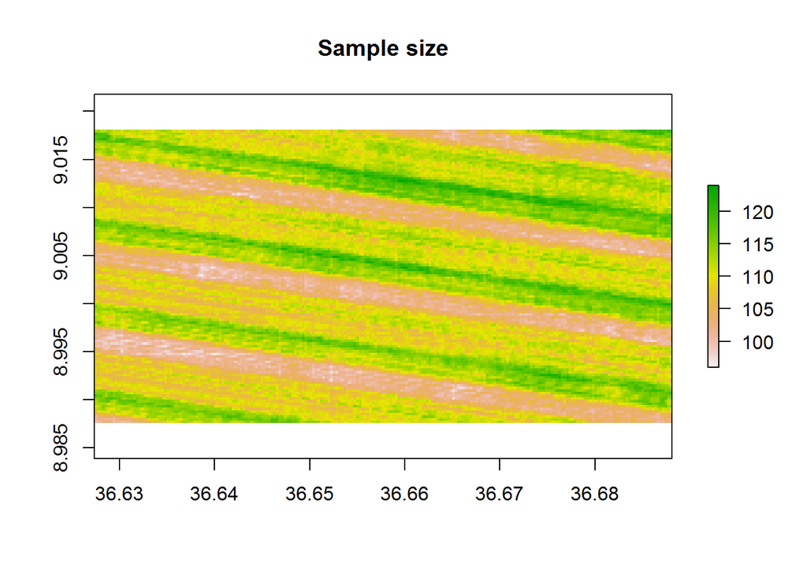

```r
plot(x$n, main="Sample size")
```

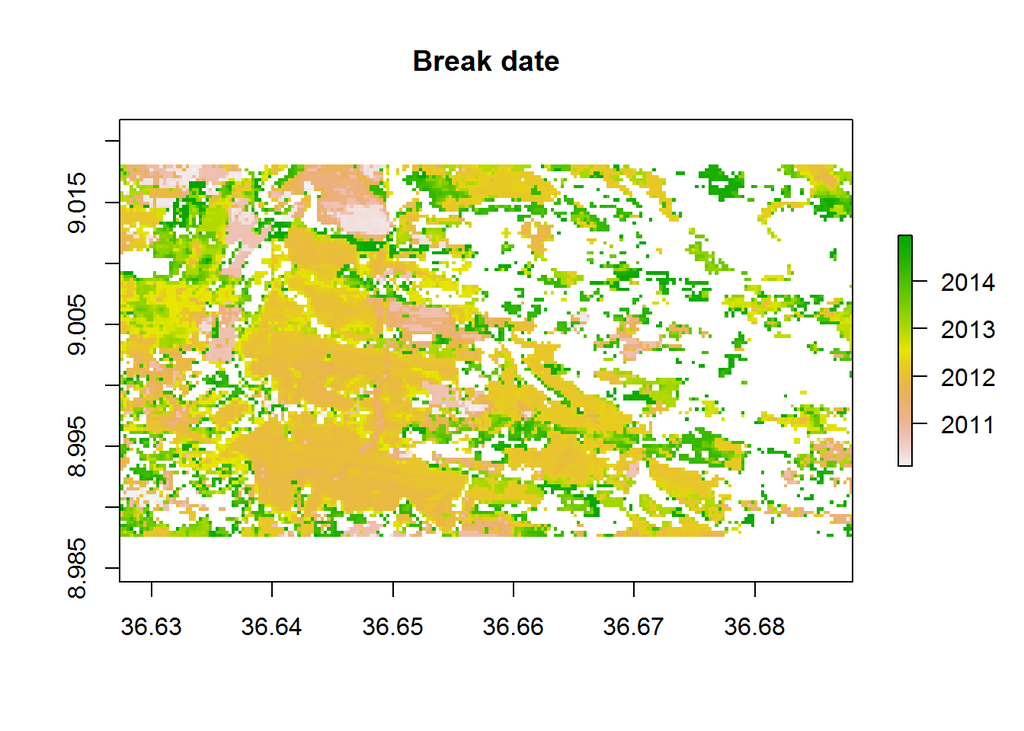

```r
plot(x$breakdate, main="Break date")
```

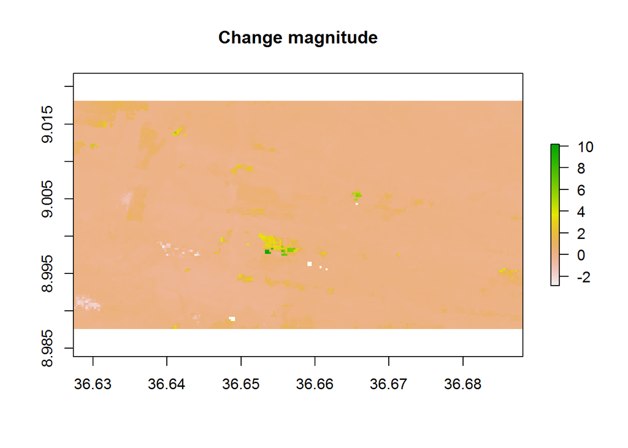

```r
plot(x$magnitude, main="Change magnitude")
```